# FINAL PROJECT- ANALYSIS OF NETFLIX DATA

[Krittika Shahani](https://krittika2000.github.io/Stat184-Final-Project/)

## Research question

**What has been the global transition in the content on Netflix in terms of TV shows to Movies over the years ?**

*Why I chose this topic* : In a day and age where everything is controlled by the internet , Netflix has taken over the entertainment industry and has been prevailing like no other platform before. Netflix provides a place for all kinds of content - web series , TV shows, Movies ,Documentries ,etc.

The main reason why Netflix is so popular is because it is accessible by people all over the world and caters to almost all age groups and genres .

It would be very interesting to see how the content has changed over the years(around 10-15) globally (while also analysing factors like duration and genres,etc.)

#### Other guiding Questions :

1. The top 10 genres over the years
2. The mean/average/typical durations of Movies and TV shows in the Top 10 countries according to viewership
3. The kind of content being released in the different countries , i.e. based on rating
4. Is there any correlation between genres and ratings or duration and ratings ?

## The two sets of data I am using :

The primary data scource lists the statistics and numbers based on content that Netflix produces.

My secondary data source analyses the data of Netflix content based on the ratings given by people .

I have tried looking and analysing the data and questions from both points of view !

```r
#loading the libraries that will be needed in the project
library(DataComputing)
library(tidyverse)
library(tidyr)
library(dplyr)
library(ggplot2)
library(mosaicData)
library(mosaic)
```

#### Accessing the 2 data sources

```r
#Loading the primary data source
library(readr)
netflix_titles <- read_csv("netflix_titles.csv")
head(netflix_titles)
```

| show_id | type | title | director | cast | country | date_added | release_year | rating | duration | listed_in | description |
| --- | --- | --- | --- | --- | --- | --- | --- | --- | --- | --- | --- |
| 81145628 | Movie | Norm of the North: King Sized Adventure | Richard Finn, Tim Maltby | Alan Marriott, Andrew Toth, Brian Dobson, Cole Howard, Jennifer Cameron, Jonathan Holmes, Lee Tockar, Lisa Durupt, Maya Kay, Michael Dobson | United States, India, South Korea, China | September 9, 2019 | 2019 | TV-PG | 90 min | Children & Family Movies, Comedies | Before planning an awesome wedding for his grandfather, a polar bear king must take back a stolen artifact from an evil archaeologist first. |
| 80117401 | Movie | Jandino: Whatever it Takes | NA | Jandino Asporaat | United Kingdom | September 9, 2016 | 2016 | TV-MA | 94 min | Stand-Up Comedy | Jandino Asporaat riffs on the challenges of raising kids and serenades the audience with a rousing rendition of "Sex on Fire" in his comedy show. |
| 70234439 | TV Show | Transformers Prime | NA | Peter Cullen, Sumalee Montano, Frank Welker, Jeffrey Combs, Kevin Michael Richardson, Tania Gunadi, Josh Keaton, Steve Blum, Andy Pessoa, Ernie Hudson, Daran Norris, Will Friedle | United States | September 8, 2018 | 2013 | TV-Y7-FV | 1 Season | Kids' TV | With the help of three human allies, the Autobots once again protect Earth from the onslaught of the Decepticons and their leader, Megatron. |
| 80058654 | TV Show | Transformers: Robots in Disguise | NA | Will Friedle, Darren Criss, Constance Zimmer, Khary Payton, Mitchell Whitfield, Stuart Allan, Ted McGinley, Peter Cullen | United States | September 8, 2018 | 2016 | TV-Y7 | 1 Season | Kids' TV | When a prison ship crash unleashes hundreds of Decepticons on Earth, Bumblebee leads a new Autobot force to protect humankind. |
| 80125979 | Movie | #realityhigh | Fernando Lebrija | Nesta Cooper, Kate Walsh, John Michael Higgins, Keith Powers, Alicia Sanz, Jake Borelli, Kid Ink, Yousef Erakat, Rebekah Graf, Anne Winters, Peter Gilroy, Patrick Davis | United States | September 8, 2017 | 2017 | TV-14 | 99 min | Comedies | When nerdy high schooler Dani finally attracts the interest of her longtime crush, she lands in the cross hairs of his ex, a social media celebrity. |
| 80163890 | TV Show | Apaches | NA | Alberto Ammann, Eloy Azorín, Verónica Echegui, Lucía Jiménez, Claudia Traisac | Spain | September 8, 2017 | 2016 | TV-MA | 1 Season | Crime TV Shows, International TV Shows, Spanish-Language TV Shows | A young journalist is forced into a life of crime to save his father and family in this series based on the novel by Miguel Sáez Carral. |

```r
#Loading the other data source
library(readxl)
netflix_data_excel_1_ <- read_excel("netflix_data_excel (1).xlsx")
```

```
-
/
```

```r
head(netflix_data_excel_1_)
```

| title | rating | ratingLevel | ratingDescription | releaseyear | user_rating_score | user_rating_size |
| --- | --- | --- | --- | --- | --- | --- |
| White Chicks | PG-13 | crude and sexual humor, language and some drug content | 80 | 2004 | 82 | 80 |
| Lucky Number Slevin | R | strong violence, sexual content and adult language | 100 | 2006 | 0 | 82 |
| Grey's A0tomy | TV-14 | Parents strongly cautioned. May be unsuitable for children ages 14 and under. | 90 | 2016 | 98 | 80 |
| Prison Break | TV-14 | Parents strongly cautioned. May be unsuitable for children ages 14 and under. | 90 | 2008 | 98 | 80 |
| How I Met Your Mother | TV-PG | Parental guidance suggested. May not be suitable for all children. | 70 | 2014 | 94 | 80 |
| Super0tural | TV-14 | Parents strongly cautioned. May be unsuitable for children ages 14 and under. | 90 | 2016 | 95 | 80 |

#### Cleaning the data

While working with huge amounts of unfiltered raw data , sometimes we encounter lots of missing values, values like date and time that have not been formatted correctly. In order to run our data wrangling codes and get good visuals it is important for us to filter and clean the data before we put it to use. It is also important to nullify unimportant data.

```r
#cleaning the data and droppping show_id and description columns
netflix_titles = subset(netflix_titles, select = -c(show_id,description) )
#Changing the below variables in categorical variables
netflix_titles$rating <- as.factor(netflix_titles$rating)
netflix_titles$listed_in <- as.factor(netflix_titles$listed_in)
netflix_titles$type <- as.factor(netflix_titles$type)
```

### Division based on Content Type on Netflix

Let’s first take a look at the two broad components that the content on Netflix can be divided into - mainly **Movies** and **TV Shows** We can see the proportion of each easily through the pie chart below!

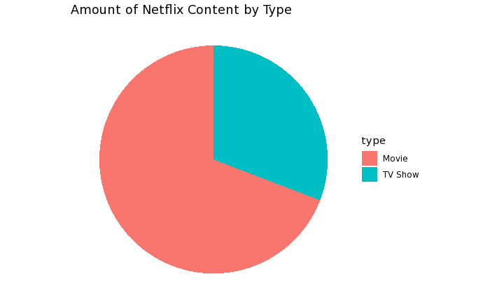

```r
##diving by content type
count_by_type <-
  netflix_titles%>%
  group_by(type) %>%
  summarise(count = n())
# Data visualisation
ggplot(count_by_type, aes(x='', y=count, fill=type)) + ggtitle("Amount of Netflix Content by Type") +geom_bar(stat="identity", width=1) +coord_polar("y", start=0) + theme_void()
```

**It can clearly be seen that the number of movies is much more on Netflix than TV Shows**

### Division of rating on the two types of content on Netflix

In this part of the analysis , we can use the graph to show that based on each rating - how many of them are movies and how many are TV Shows. We can also see which rating is most popular in movies and which is most popular in TV Shows.

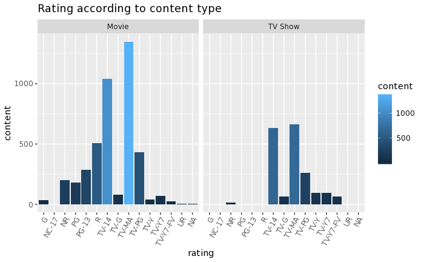

```r
#wrangling by rating type
ratings <-netflix_titles %>%
  group_by(rating, type) %>%
  summarise(content_num = n()) %>%
  arrange(desc(content_num))
names(ratings) [1] <- "rating"
names(ratings) [2] <- "type"
names(ratings) [3] <- "content"
#visualisation
ggplot(data=ratings,aes(x=rating,y=content ,fill=content))+geom_bar(stat='identity',position='stack', width=.9) + theme(axis.text.x=element_text(angle=60,hjust=1))+ facet_wrap(~type,ncol=3)+ggtitle("Rating according to content type")
```

**The TV-MA has the highest number of movies with that rating . TV Shows also has TV-MA as the highest rating**

### Top 10 Genres globally , over the years(based on total count on Netflix)

Let’s now take a look at the Top 10 genres that have been produced over the years. This gives us an idea as to which demographic is mostly catered to by Netflix and which type of content has been in high demand and hence been produced by Netflix !

```r
#code to find top 10 genres from the netfilx_titles table
Top10<-
  netflix_titles %>%
    group_by(listed_in)%>%
    summarise(total=n())%>%
    arrange(desc(total)) %>%
    head(10)
Top10
```

| listed_in | total |
| --- | --- |
| Documentaries | 299 |
| Stand-Up Comedy | 273 |
| Dramas, International Movies | 248 |
| Dramas, Independent Movies, International Movies | 186 |
| Comedies, Dramas, International Movies | 174 |
| Kids' TV | 153 |
| Documentaries, International Movies | 150 |
| Children & Family Movies, Comedies | 129 |
| Children & Family Movies | 120 |
| Comedies, International Movies | 120 |

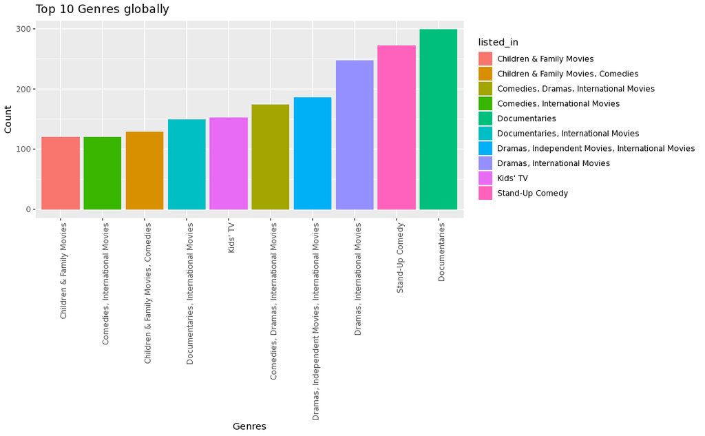

```r
#par(mar=c(10,10,10,10))
ggplot(data=Top10,aes(x=reorder(listed_in,total),y=total ,fill=listed_in))+geom_bar(stat='identity',position='stack', width=.9) + theme(axis.text.x=element_text(angle=90,hjust=1))+xlab("Genres")+ylab("Count")+ggtitle("Top 10 Genres globally")
```

**As we see from the graph Documentries lead the charts, with Stand up comedy as a close second and so on**

### Duration of the movies released over the years in the top 10 Countries

This shows the duration of movies in the top 10 countries . It is important to take a look at this data as we can analyse if movies that are longer are more popular or do people like watching short movies.

```r
##calculating duration of movies based on top 10 countries
CountryM_Duration<-
  na.omit(netflix_titles[netflix_titles$type=="Movie",][,c("country", "duration")])
##regex for splitting
 s1 <-
   strsplit(CountryM_Duration$country, split = ", ")

  CountryM_Duration_full <-
    data.frame(duration = rep(CountryM_Duration$duration, sapply(s1, length)), country = unlist(s1))
#converting to nummeric
  CountryM_Duration_full$duration <-
    as.numeric(gsub(" min","", CountryM_Duration_full$duration))
#top 10 country names
  CountryM_Duration_full_subset<-
    CountryM_Duration_full[CountryM_Duration_full$country %in% c("United States", "India", "United Kingdom", "Canada", "France", "Japan", "Spain", "South Korea", "Mexico", "Australia"),]
```

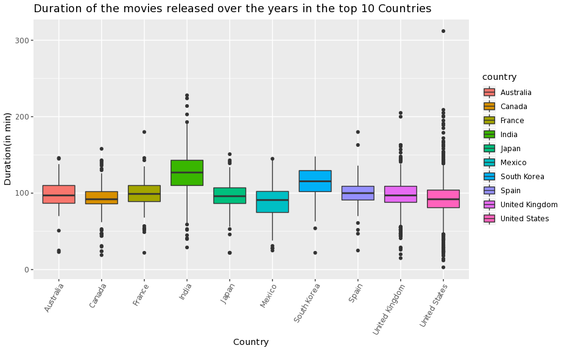

```r
##Graph(box and whishker plot) showing duration of movies in top 10 countries
CountryM_Duration_full_subset%>%
  ggplot(aes(x=country,y=duration,fill=country))+geom_boxplot()+theme(axis.text.x=element_text(angle=60,hjust=1))+xlab("Country")+ylab("Duration(in min)")+ggtitle("Duration of the movies released over the years in the top 10 Countries")
```

### In each year what kinds of movies were released based on Rating Desription

In the table “netflix_data_excel” the rating level/genres also have a corrensponding ratingDescription which is a quantitative variable . It has various levels like , 10: movies that are suitable for all ages and 110 which are movies only suitable for adults and not for children . So the higher the number the less suitable the movie is for a universal audience that include children.

The graph below shows the various kinds of movies and the number of them that have been produced on Netflix.

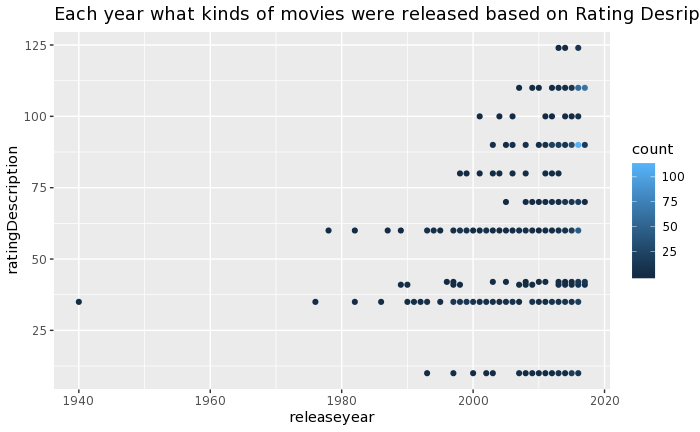

```r
##finding rating description over the years
most_popular <-
  netflix_data_excel_1_ %>%
  group_by(ratingDescription,releaseyear) %>%
  summarise(count = n())
##plotting above calculations
ggplot(data=most_popular,aes(x=releaseyear,y=ratingDescription))+geom_point()+aes(colour=count)+ggtitle("Each year what kinds of movies were released based on Rating Desription")
```

### Which 10 genres of movies are most popular amongst people over the years based on user rating score

Just like we had a graph above that gave top 10 genres released by Netflix , this data actually gives us the genres that have been top rated by the people themselves. Over the years , the movies and content type on Netflix have been watched by people and have been given ratings. This analysis is based on those ratings. So let’s take a look at the global response of the people .

The rating scores follow the general norm- the higher the rating (out of a total of 100) the more the people have liked the movie.

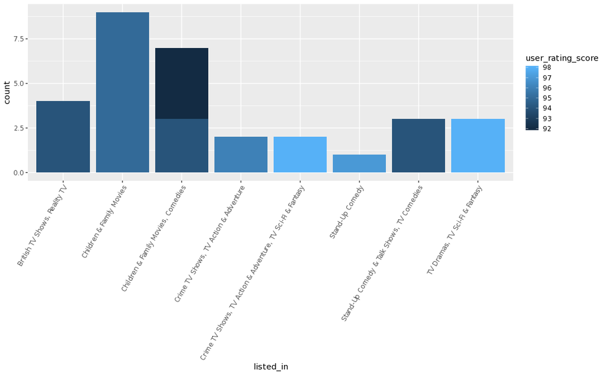

```r
##joining tables by title to find common movies
joining_tb<-
  left_join(netflix_data_excel_1_,netflix_titles,by=c("title"="title"))
## grouping based on user rating and finding top 10
popular<-
  joining_tb%>%
  na.omit(joining_tb)%>%
  group_by(listed_in,user_rating_score,releaseyear)%>%
  summarise(count=n())%>%
  arrange(desc(user_rating_score))%>%
  head(10)
ggplot(data=popular,aes(x=listed_in,y=count,order=reorder(releaseyear,releaseyear),fill=user_rating_score))+geom_bar(stat='identity',position='stack', width=.9) + theme(axis.text.x=element_text(angle=60,hjust=1))
```

**Our visual analysis tells us that TV Dramas and Crime TV Shows have been given highest rating , but the audience for Children and family movies are more in number and hence more number of people have rated it**

### Which year had the highest content rating according to the ratings given by people?

The graph below shows year wise , the content user rating that was given to movies on Netflix. The graph shows us the transition of how many ratings people gave and thereby shows us how many shows people watched .

```r
##grouping data based on release year and user rating
popular<-
  joining_tb%>%
  na.omit(joining_tb)%>%
  group_by(listed_in,user_rating_score,releaseyear)%>%
  summarise(count=n())%>%
  arrange(desc(user_rating_score))
```

```r
##spreading the table to get an idea - year wise
popular%>%
  spread(key=releaseyear,value = user_rating_score)
```

| listed_in | count | 1978 | 1986 | 1991 | 1995 | 1998 | 1999 | 2001 | 2003 | 2005 | 2006 | 2007 | 2009 | 2013 | 2014 | 2015 | 2016 | 2017 |
| --- | --- | --- | --- | --- | --- | --- | --- | --- | --- | --- | --- | --- | --- | --- | --- | --- | --- | --- |
| Action & Adventure, Comedies | 1 | NA | NA | NA | NA | NA | NA | NA | NA | NA | NA | NA | NA | NA | NA | NA | 84 | NA |
| Action & Adventure, Sci-Fi & Fantasy, Thrillers | 2 | NA | NA | NA | NA | NA | NA | NA | NA | NA | NA | NA | NA | NA | NA | NA | 84 | NA |
| British TV Shows, Reality TV | 4 | NA | NA | NA | NA | NA | NA | NA | NA | NA | NA | NA | NA | NA | NA | NA | 94 | NA |
| Children & Family Movies | 1 | NA | NA | NA | NA | NA | NA | NA | NA | NA | NA | NA | NA | 0 | NA | 71 | NA | NA |
| Children & Family Movies | 2 | NA | NA | NA | NA | NA | NA | NA | NA | NA | NA | NA | NA | NA | NA | 0 | NA | NA |
| Children & Family Movies | 3 | NA | NA | NA | NA | NA | NA | NA | NA | NA | NA | NA | NA | NA | 57 | 84 | NA | NA |
| Children & Family Movies | 4 | NA | 67 | NA | NA | NA | 0 | NA | NA | NA | NA | NA | 95 | NA | NA | NA | NA | NA |
| Children & Family Movies | 5 | NA | NA | 0 | NA | NA | 95 | 0 | NA | NA | NA | NA | NA | NA | NA | NA | NA | NA |
| Children & Family Movies, Comedies | 1 | NA | NA | NA | NA | NA | NA | NA | 64 | NA | NA | NA | NA | NA | 0 | NA | NA | NA |
| Children & Family Movies, Comedies | 2 | NA | NA | NA | NA | NA | NA | NA | NA | NA | NA | NA | NA | NA | NA | NA | 0 | NA |

[output cut: 28 more lines]

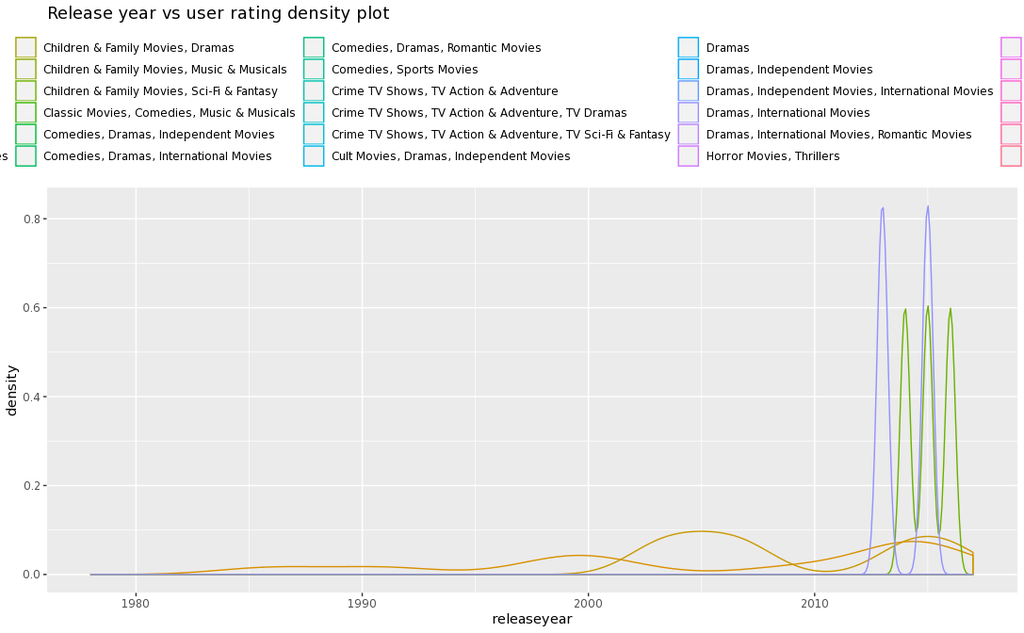

```r
ggplot( data = popular, aes(x = releaseyear)) + geom_density(adjust = 0.4) + aes(colour = listed_in) + labs(title = "") + theme(legend.position = "top")+ggtitle("Release year vs user rating density plot")
```

### Testing correlation between Rating Description and User ratings

This is a correlation test that shows if the rating description(i.e.kind of movies- universal or adult) is in any way related to how high the user rating is !

```r
##finding correlation coefficient by pearson's method
cor.test(joining_tb$ratingDescription,joining_tb$user_rating_score,method="pearson")
```

```
    Pearson's product-moment correlation

data:  x and y
t = 8.243, df = 1014, p-value = 5.158e-16
alternative hypothesis: true correlation is not equal to 0
95 percent confidence interval:
 0.1920579 0.3073661
sample estimates:
      cor
0.2506006
```

### Analysis and calculation of the average number of people who are actually rating the content on Netflix and the Average rating score for each kind of content from the people !

```r
avg_data<-
  netflix_data_excel_1_ %>%
  group_by(ratingLevel)%>%
  summarise(avg_size= mean(user_rating_size, na.rm = TRUE),
            avg_scores= mean(user_rating_score))
avg_data
```

| ratingLevel | avg_size | avg_scores |
| --- | --- | --- |
| action and rude humor | 80.00000 | 96.00000 |
| action and some rude humor | 80.00000 | 74.00000 |
| action and violence throughout, and mild language | 82.00000 | 0.00000 |
| action sequences and peril | 80.00000 | 64.00000 |
| action violence | 80.00000 | 96.00000 |
| action violence throughout, some scary images, and language | 82.00000 | 0.00000 |
| action violence, language and rude humor | 80.00000 | 91.00000 |
| adult content and mld violence | 80.00000 | 68.00000 |
| adult content, adult language and mild violence | 80.00000 | 68.00000 |
| animal action and humor | 82.00000 | 0.00000 |

[output cut: 90 more lines]

### Problems I came accross and how I overcame it:

The first issue that I came across was that the data sets I was running my codes on , were too large to construct a plot on . In some cases I was getting an error and no output visualisation. To overcome this problem , in some questions , I had to reduce the size of the data being analysed , i.e. base my analysis on the top 10 (10 most important and largest counts)or so. This way my calculations weren’t affected too much and also I was able to get a good visualisation and set the scale.

### Conclusion:

In conclusion I would like to state that my analysis was based on a lot of factors that affect the content on Netflix- like content type(movie or tv show), the duration of the content, the rating given by netflix,the genres and the rating given by people .

Over the years the content on Netflix has transitioned so much : genres have changed by becoming available in many languages(thereby catering to various countries) , they have also been created in such a way that a child, a teen, an adults and the older generation can enjoy Netflix in their respective ways ! We can see that gradually progressing through the years, the audience numbers have increased(given more ratings)and so have the numbers of movies and TV shows.

### Data Sources and sites:(citation)

##### Primary Source : https://www.kaggle.com/shivamb/netflix-shows

##### Other Sources : https://data.world/chasewillden/netflix-shows